# Storm Research

Ian Wheeler

2023-12-29

## Abstract

The following is a basic analysis of severe weather data from the U.S. National Oceanic and Atmospheric Administration’s (NOAA) storm database. This database contains information from 1950 to 2011 related to the characteristics of major storms and weather events in the United States, including injuries, fatalities, and property damage. This analysis addresses the questions of which types of severe weather events are most harmful with respect to population health and which types of events have the greatest economic consequences. The researcher has selected property damage estimates and injuries as the metrics by which to measure economic impact and harm to population health respectively.

## Results

The data indicate clearly that tornadoes are the most costly severe weather events in terms of personal injuries, while floods are the most costly in terms of estimated property damage.

## Data Processing

```r
setwd("~/R for DS/StormResearch/")
```

```r
library(tidyverse)
```

```r
library(ggplot2)
library(httr)
library(readr)

# Set source url
url <- "https://d396qusza40orc.cloudfront.net/repdata%2Fdata%2FStormData.csv.bz2"

# Save local file destination
src <- "src/StormData.bz2"

# Download the file
download.file(url, destfile = src, method = "curl")

# Read the .bzip2 file into a data frame
df <- read.csv(pipe(paste("bzcat", src)), header = TRUE)
```

## Explore Data

```r
head(df,10)
```

```
##    STATE__           BGN_DATE BGN_TIME TIME_ZONE COUNTY COUNTYNAME STATE
## 1        1  4/18/1950 0:00:00     0130       CST     97     MOBILE    AL
## 2        1  4/18/1950 0:00:00     0145       CST      3    BALDWIN    AL
## 3        1  2/20/1951 0:00:00     1600       CST     57    FAYETTE    AL
## 4        1   6/8/1951 0:00:00     0900       CST     89    MADISON    AL
## 5        1 11/15/1951 0:00:00     1500       CST     43    CULLMAN    AL
## 6        1 11/15/1951 0:00:00     2000       CST     77 LAUDERDALE    AL
## 7        1 11/16/1951 0:00:00     0100       CST      9     BLOUNT    AL
## 8        1  1/22/1952 0:00:00     0900       CST    123 TALLAPOOSA    AL
## 9        1  2/13/1952 0:00:00     2000       CST    125 TUSCALOOSA    AL
## 10       1  2/13/1952 0:00:00     2000       CST     57    FAYETTE    AL
##     EVTYPE BGN_RANGE BGN_AZI BGN_LOCATI END_DATE END_TIME COUNTY_END COUNTYENDN
## 1  TORNADO         0                                               0         NA
## 2  TORNADO         0                                               0         NA
## 3  TORNADO         0                                               0         NA
```

[output cut: 40 more lines]

```r
summary(df)
```

```
##     STATE__       BGN_DATE           BGN_TIME          TIME_ZONE
##  Min.   : 1.0   Length:902297      Length:902297      Length:902297
##  1st Qu.:19.0   Class :character   Class :character   Class :character
##  Median :30.0   Mode  :character   Mode  :character   Mode  :character
##  Mean   :31.2
##  3rd Qu.:45.0
##  Max.   :95.0
##
##      COUNTY     COUNTYNAME           STATE              EVTYPE
##  Min.   :  0   Length:902297      Length:902297      Length:902297
##  1st Qu.: 31   Class :character   Class :character   Class :character
##  Median : 75   Mode  :character   Mode  :character   Mode  :character
##  Mean   :101
##  3rd Qu.:131
##  Max.   :873
##
##    BGN_RANGE         BGN_AZI           BGN_LOCATI          END_DATE
##  Min.   :   0.00   Length:902297      Length:902297      Length:902297
##  1st Qu.:   0.00   Class :character   Class :character   Class :character
##  Median :   0.00   Mode  :character   Mode  :character   Mode  :character
##  Mean   :   1.48
##  3rd Qu.:   1.00
##  Max.   :3749.00
##
##    END_TIME           COUNTY_END COUNTYENDN       END_RANGE
##  Length:902297      Min.   :0    Mode:logical   Min.   :  0.000
##  Class :character   1st Qu.:0    NA's:902297    1st Qu.:  0.000
##  Mode  :character   Median :0                   Median :  0.000
##                     Mean   :0                   Mean   :  0.986
##                     3rd Qu.:0                   3rd Qu.:  0.000
##                     Max.   :0                   Max.   :925.000
##
##    END_AZI           END_LOCATI            LENGTH            WIDTH
##  Length:902297      Length:902297      Min.   :   0.00   Min.   :   0.0
##  Class :character   Class :character   1st Qu.:   0.00   1st Qu.:   0.0
##  Mode  :character   Mode  :character   Median :   0.00   Median :   0.0
##                                        Mean   :   0.23   Mean   :   7.5
##                                        3rd Qu.:   0.00   3rd Qu.:   0.0
##                                        Max.   :2315.00   Max.   :4400.0
##
```

[output cut: 25 more lines]

```
##  Min.   :-14451   Min.   :   0   Min.   :-14455   Length:902297
##  1st Qu.:  7247   1st Qu.:   0   1st Qu.:     0   Class :character
##  Median :  8707   Median :   0   Median :     0   Mode  :character
##  Mean   :  6940   Mean   :1452   Mean   :  3509
##  3rd Qu.:  9605   3rd Qu.:3549   3rd Qu.:  8735
##  Max.   : 17124   Max.   :9706   Max.   :106220
##                   NA's   :40
##      REFNUM
##  Min.   :     1
##  1st Qu.:225575
##  Median :451149
##  Mean   :451149
##  3rd Qu.:676723
##  Max.   :902297
##
```

## Clean up formatting and filter data

Because the earlier years represented in the database record fewer events and are less reliable due to inferior record-keeping, this analysis focuses on the 25 year period from 1986 to 2011.

```r
beg <- ymd("1986-01-01", tz = "America/Chicago")
end <- ymd("2011-11-30", tz = "America/Chicago")

# Convert BGD_DATE field from character to date; Create normalized property
# damage field by using PROPDMG value multiplied by the PROPDMGEXP value. The
# property damage is normalized to represent millions of dollars.
df <- df %>%
        mutate(DMGCOSTNORM = case_when(
                PROPDMGEXP == "M" ~ (PROPDMG * 1000000),
                PROPDMGEXP == "B" ~ (PROPDMG * 1000000000),
                PROPDMG > 0 ~ (PROPDMG * 1000)),
               DMGCOSTNORM = ifelse(DMGCOSTNORM > 0, DMGCOSTNORM / 1000000,
                                    DMGCOSTNORM),
               BGN_DATE = mdy_hms(BGN_DATE, tz = "America/Chicago")) %>%
        filter(BGN_DATE >= beg, BGN_DATE <= end) %>%
        relocate(DMGCOSTNORM, .before = CROPDMG)
```

```r
# Analyze Event Types by Injury count
injuries <- df %>%
  group_by(EVTYPE) %>%
  summarize(totalInjuries = sum(INJURIES, na.rm = TRUE)) %>%
        filter(totalInjuries > 50) %>%
  arrange(desc(totalInjuries))

# Display top 5 injurious events
head(injuries, 5)
```

```
## # A tibble: 5 × 2
##   EVTYPE         totalInjuries
##   <chr>                  <dbl>
## 1 TORNADO                30186
## 2 FLOOD                   6789
## 3 EXCESSIVE HEAT          6525
## 4 TSTM WIND               6418
## 5 LIGHTNING               5230
```

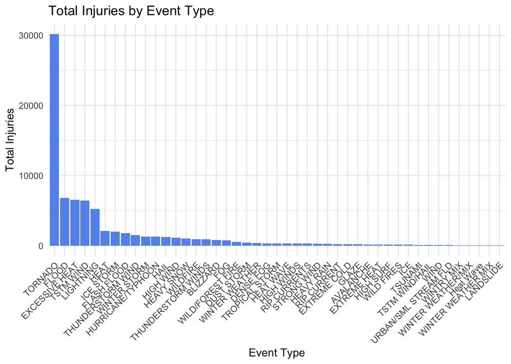

```r
# Create a bar plot showing injuries counts by events with more than 50 injuries
ggplot(injuries, aes(x = reorder(EVTYPE, -totalInjuries), y = totalInjuries)) +
  geom_bar(stat = "identity", fill = "cornflowerblue") +
  labs(title = "Total Injuries by Event Type",
       x = "Event Type",
       y = "Total Injuries") +
  theme_minimal() +
  theme(axis.text.x = element_text(angle = 45, hjust = 1))
```

```r
# Calculate total injuries from severe weather events and total minus tornadoes.
allInj <- sum(df$INJURIES)
twisterInj <- df %>%
        filter(EVTYPE == "TORNADO") %>%
        summarize(twistInj = sum(INJURIES))
allTornado <- twisterInj[1,1]
allOthers <- allInj - allTornado
```

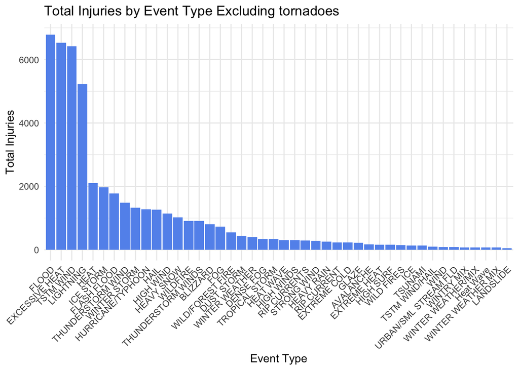

```r
# Plot non-tornado injuries
nonTornado <- df %>%
  group_by(EVTYPE) %>%
  summarize(totalInjuries = sum(INJURIES, na.rm = TRUE)) %>%
        filter(totalInjuries > 50,
               EVTYPE != "TORNADO") %>%
  arrange(desc(totalInjuries))

# Create a bar plot showing injuries counts by non-Tornado events with more than
# 50 injuries
ggplot(nonTornado, aes(x = reorder(EVTYPE, -totalInjuries), y = totalInjuries)) +
  geom_bar(stat = "identity", fill = "cornflowerblue") +
  labs(title = "Total Injuries by Event Type Excluding tornadoes",
       x = "Event Type",
       y = "Total Injuries") +
  theme_minimal() +
  theme(axis.text.x = element_text(angle = 45, hjust = 1))
```

## Property Damage

```r
# Analyze Event Types by Injury count
damage <- df %>%
  group_by(EVTYPE) %>%
  summarize(totalDamage = sum(DMGCOSTNORM, na.rm = TRUE)) %>%
        filter(totalDamage > 500) %>%
  arrange(desc(totalDamage))

# Display the 5 most costly events in terms of property damage estimates
head(damage, 5)
```

```
## # A tibble: 5 × 2
##   EVTYPE            totalDamage
##   <chr>                   <dbl>
## 1 FLOOD                 144658.
## 2 HURRICANE/TYPHOON      69306.
## 3 STORM SURGE            43324.
## 4 TORNADO                34774.
## 5 FLASH FLOOD            16141.
```

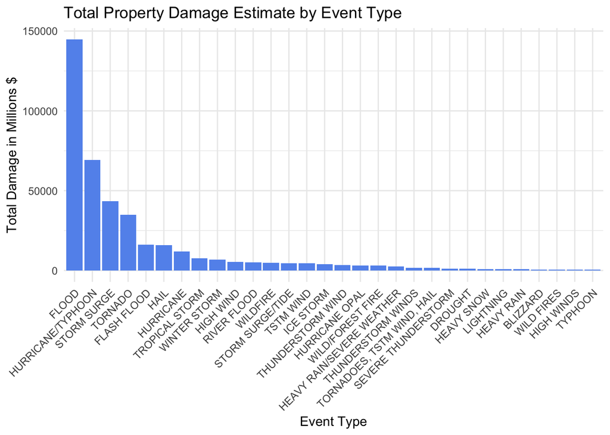

```r
# Create a bar plot showing injuries counts by events with more than 50 injuries
ggplot(damage, aes(x = reorder(EVTYPE, -totalDamage), y = totalDamage)) +
  geom_bar(stat = "identity", fill = "cornflowerblue") +
  labs(title = "Total Property Damage Estimate by Event Type",
       x = "Event Type",
       y = "Total Damage in Millions $") +
  theme_minimal() +
  theme(axis.text.x = element_text(angle = 45, hjust = 1))
```